# Analiza wariancji

Adam Michalski

```r
library(datasets)
library(dplyr, warn = FALSE)
data(iris)
attach(iris)
sep_len <-  Sepal.Length
sep_wid <- Sepal.Width
spec <- Species
detach(iris)
groups <- group_by(iris, Species)
summarise(groups, group_mean = mean(Sepal.Length))
```

```
## # A tibble: 3 × 2
##   Species    group_mean
##   <fct>           <dbl>
## 1 setosa           5.01
## 2 versicolor       5.94
## 3 virginica        6.59
```

```r
summarise(groups, group_var =var(Sepal.Length))
```

```
## # A tibble: 3 × 2
##   Species    group_var
##   <fct>          <dbl>
## 1 setosa         0.124
## 2 versicolor     0.266
## 3 virginica      0.404
```

```r
summarise(groups, group_mean =mean(Sepal.Width))
```

```
## # A tibble: 3 × 2
##   Species    group_mean
##   <fct>           <dbl>
## 1 setosa           3.43
## 2 versicolor       2.77
## 3 virginica        2.97
```

```r
summarise(groups, group_var =var(Sepal.Width))
```

```
## # A tibble: 3 × 2
##   Species    group_var
##   <fct>          <dbl>
## 1 setosa        0.144
## 2 versicolor    0.0985
## 3 virginica     0.104
```

```r
for (column in c('setosa', 'versicolor', 'virginica')){
  cat("\nGatunek", column, ":\n")
  print(shapiro.test(sep_len[spec == column]))
  print(shapiro.test(sep_wid[spec == column]))
}
```

```
##
## Gatunek setosa :
##
##  Shapiro-Wilk normality test
##
## data:  sep_len[spec == column]
## W = 0.9777, p-value = 0.4595
##
##
##  Shapiro-Wilk normality test
##
## data:  sep_wid[spec == column]
## W = 0.97172, p-value = 0.2715
##
##
## Gatunek versicolor :
##
##  Shapiro-Wilk normality test
##
## data:  sep_len[spec == column]
## W = 0.97784, p-value = 0.4647
##
##
##  Shapiro-Wilk normality test
##
## data:  sep_wid[spec == column]
## W = 0.97413, p-value = 0.338
##
##
## Gatunek virginica :
##
##  Shapiro-Wilk normality test
##
## data:  sep_len[spec == column]
## W = 0.97118, p-value = 0.2583
##
##
##  Shapiro-Wilk normality test
##
## data:  sep_wid[spec == column]
## W = 0.96739, p-value = 0.1809
```

```r
bartlett.test(sep_len ~ spec)
```

```
##
##  Bartlett test of homogeneity of variances
##
## data:  sep_len by spec
## Bartlett's K-squared = 16.006, df = 2, p-value = 0.0003345
```

```r
bartlett.test(sep_wid ~ spec)
```

```
##
##  Bartlett test of homogeneity of variances
##
## data:  sep_wid by spec
## Bartlett's K-squared = 2.0911, df = 2, p-value = 0.3515
```

```r
anova(aov(sep_len ~ spec))
```

```
## Analysis of Variance Table
##
## Response: sep_len
##            Df Sum Sq Mean Sq F value    Pr(>F)
## spec        2 63.212  31.606  119.26 < 2.2e-16 ***
## Residuals 147 38.956   0.265
## ---
## Signif. codes:  0 '***' 0.001 '**' 0.01 '*' 0.05 '.' 0.1 ' ' 1
```

```r
anova(aov(sep_wid ~ spec))
```

```
## Analysis of Variance Table
##
## Response: sep_wid
##            Df Sum Sq Mean Sq F value    Pr(>F)
## spec        2 11.345  5.6725   49.16 < 2.2e-16 ***
## Residuals 147 16.962  0.1154
## ---
## Signif. codes:  0 '***' 0.001 '**' 0.01 '*' 0.05 '.' 0.1 ' ' 1
```

```r
TukeyHSD(aov(sep_len ~ spec))
```

```
##   Tukey multiple comparisons of means
##     95% family-wise confidence level
##
## Fit: aov(formula = sep_len ~ spec)
##
## $spec
##                       diff       lwr       upr p adj
## versicolor-setosa    0.930 0.6862273 1.1737727     0
## virginica-setosa     1.582 1.3382273 1.8257727     0
## virginica-versicolor 0.652 0.4082273 0.8957727     0
```

```r
TukeyHSD(aov(sep_wid ~ spec))
```

```
##   Tukey multiple comparisons of means
##     95% family-wise confidence level
##
## Fit: aov(formula = sep_wid ~ spec)
##
## $spec
##                        diff         lwr        upr     p adj
## versicolor-setosa    -0.658 -0.81885528 -0.4971447 0.0000000
## virginica-setosa     -0.454 -0.61485528 -0.2931447 0.0000000
## virginica-versicolor  0.204  0.04314472  0.3648553 0.0087802
```

Na podstawie wyniku analizy wariancji możemy przyjąć iż istnieje istotna statystycznie różnica w średnich wymiarach kwiatków różnych gatunków. Dodatkowo, z testu Tukeya wynika, że wszystkie średnie wymiary płatków różnią się parami między sobą. Założenia anovy są jednak spełnione jedynie w przypadku szerekości kielichów kwatów. Wobec tego do zbadania średniej długości kielichów kwiatów różnych gatunków możnaby było zastosować podejście Monte Carlo do dokładniejszej weryfikacji tej hipotezy.

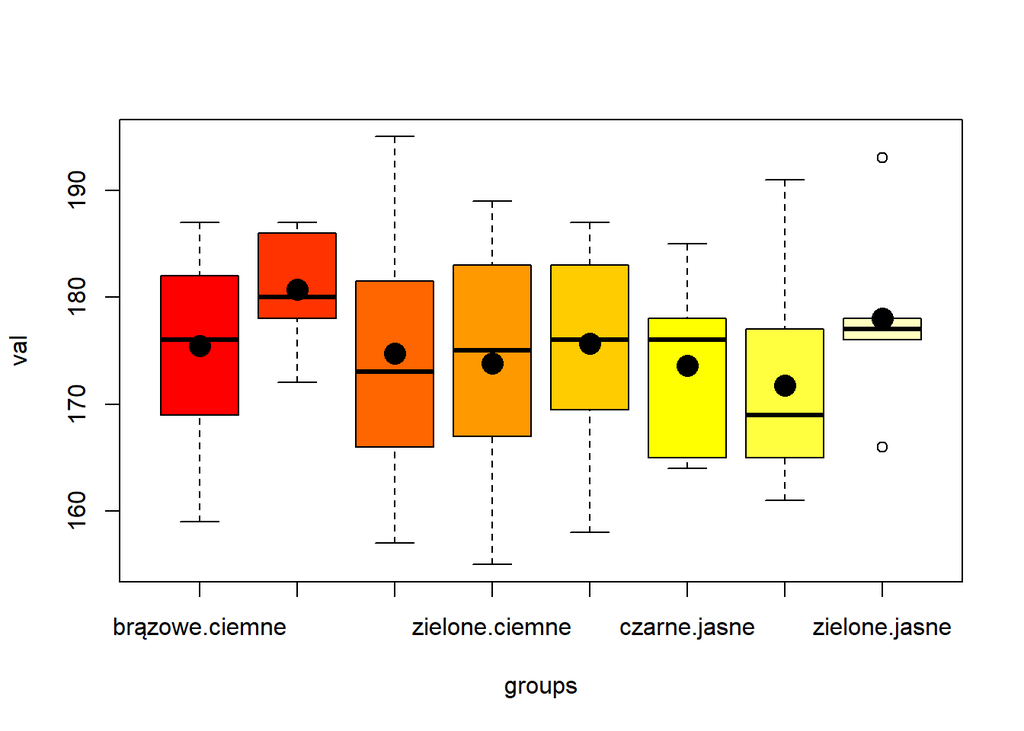

```r
height <- read.csv2("Wzrost_zal.csv", header=TRUE, fileEncoding = "Windows-1250")
attach(height)
eye_col <- kolor.oczu
hair_col <- kolor.włosów
val <- wzrost..cm.
detach(height)
groups <- interaction(eye_col, hair_col, drop = TRUE)
boxplot(val~groups, col = heat.colors(8))
points(1:8, by(val, groups, mean), pch=16, cex = 2)
```

```r
normality_results <- tapply(val, groups, shapiro.test)
for (column in names(normality_results)) {
  cat("\nGroup:", column, "\n")
  print(normality_results[[column]])
}
```

```
##
## Group: brązowe.ciemne
##
##  Shapiro-Wilk normality test
##
## data:  X[[i]]
## W = 0.96746, p-value = 0.6523
##
##
## Group: czarne.ciemne
##
##  Shapiro-Wilk normality test
##
## data:  X[[i]]
## W = 0.91486, p-value = 0.3161
##
##
## Group: niebieskie.ciemne
##
##  Shapiro-Wilk normality test
##
## data:  X[[i]]
## W = 0.95527, p-value = 0.2177
##
##
## Group: zielone.ciemne
##
##  Shapiro-Wilk normality test
##
## data:  X[[i]]
## W = 0.96075, p-value = 0.2713
##
##
## Group: brązowe.jasne
##
##  Shapiro-Wilk normality test
##
## data:  X[[i]]
## W = 0.93154, p-value = 0.1849
##
```

[output cut: 8 more lines]

```
##
## Group: niebieskie.jasne
##
##  Shapiro-Wilk normality test
##
## data:  X[[i]]
## W = 0.90302, p-value = 0.02136
##
##
## Group: zielone.jasne
##
##  Shapiro-Wilk normality test
##
## data:  X[[i]]
## W = 0.908, p-value = 0.4556
```

```r
bartlett.test(val ~ groups)
```

```
##
##  Bartlett test of homogeneity of variances
##
## data:  val by groups
## Bartlett's K-squared = 7.5408, df = 7, p-value = 0.3748
```

```r
anova(aov(val ~ eye_col*hair_col))
```

```
## Analysis of Variance Table
##
## Response: val
##                   Df  Sum Sq Mean Sq F value Pr(>F)
## eye_col            3   329.2 109.726  1.3382 0.2644
## hair_col           1    64.1  64.084  0.7815 0.3782
## eye_col:hair_col   3   303.9 101.300  1.2354 0.2992
## Residuals        142 11643.5  81.997
```

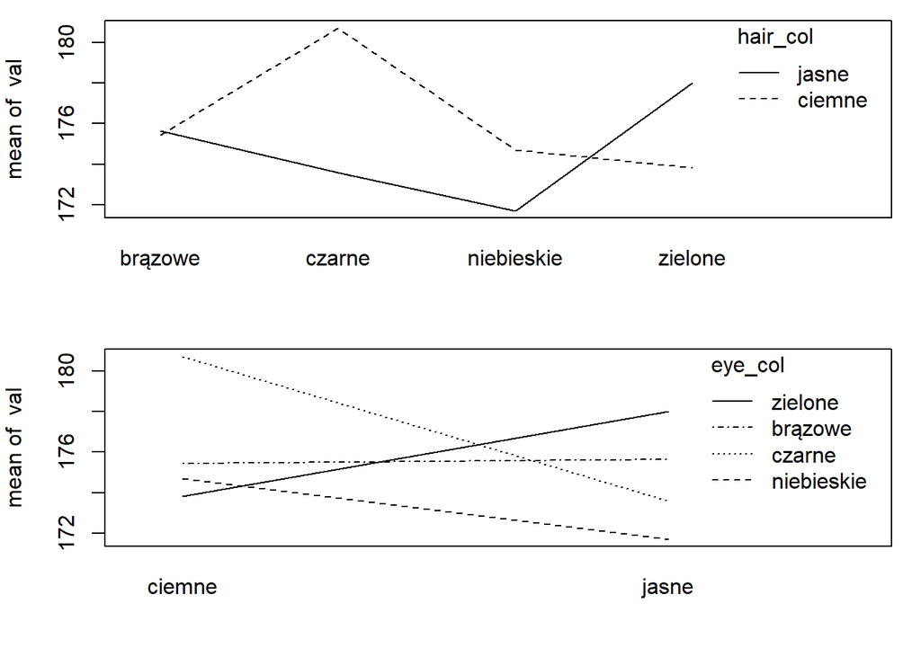

```r
op=par(mfrow=c(2,1))
par(mar=c(4.2, 4, 0.8, 1.1))
interaction.plot(eye_col, hair_col, val, xlab="")
interaction.plot(hair_col, eye_col, val, xlab="")
```

Na podstawie powyższych testów nie mamy podstaw do odrzucenia założenia dotyczącego równości wariancji w poszczególnych grupach. Jedynie w grupie osób o niebieskim kolorze oczu oraz jasnych włosach założenie normalności nie jest spełnione.

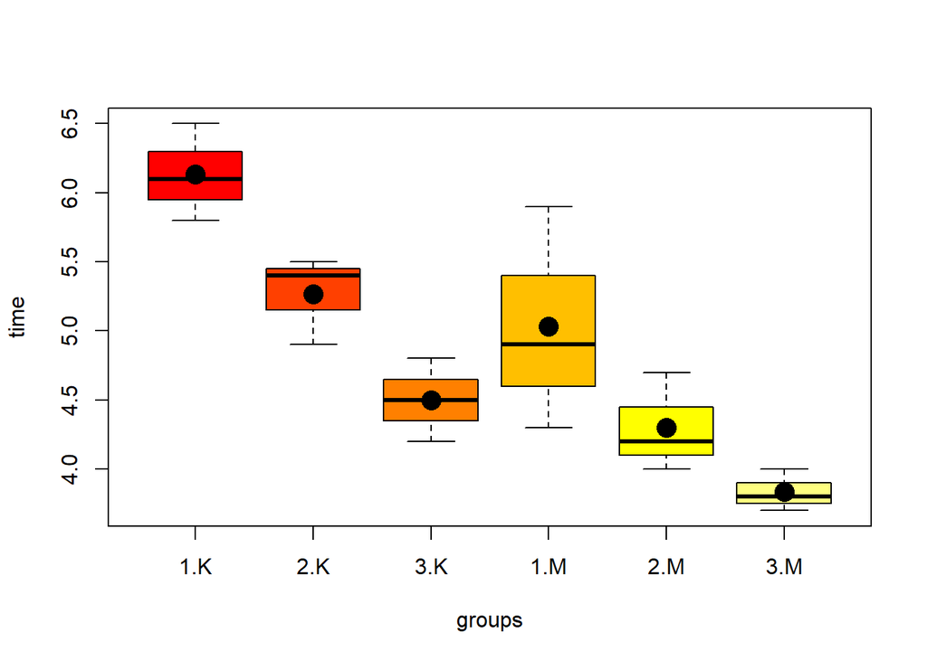

```r
time_of_completion <- read.csv2("czas_wykonania.csv", header=TRUE)
attach(time_of_completion)
time <- czas
qualifications <- kwalifikacje
gender <- plec
detach(time_of_completion)
groups <- interaction(qualifications, gender, drop = TRUE)
boxplot(time~groups, col = heat.colors(6))
points(1:6, by(time, groups, mean), pch=16, cex = 2)
```

```r
normality_results <- tapply(time, groups, shapiro.test)
for (column in names(normality_results)) {
  cat("\nGroup:", column, "\n")
  print(normality_results[[column]])
}
```

```
##
## Group: 1.K
##
##  Shapiro-Wilk normality test
##
## data:  X[[i]]
## W = 0.99324, p-value = 0.8428
##
##
## Group: 2.K
##
##  Shapiro-Wilk normality test
##
## data:  X[[i]]
## W = 0.87097, p-value = 0.2983
##
##
## Group: 3.K
##
##  Shapiro-Wilk normality test
##
## data:  X[[i]]
## W = 1, p-value = 1
##
##
## Group: 1.M
##
##  Shapiro-Wilk normality test
##
## data:  X[[i]]
## W = 0.97959, p-value = 0.7262
##
##
## Group: 2.M
##
##  Shapiro-Wilk normality test
##
## data:  X[[i]]
## W = 0.94231, p-value = 0.5367
##
##
## Group: 3.M
##
##  Shapiro-Wilk normality test
##
## data:  X[[i]]
## W = 0.96429, p-value = 0.6369
```

```r
bartlett.test(time ~ groups)
```

```
##
##  Bartlett test of homogeneity of variances
##
## data:  time by groups
## Bartlett's K-squared = 4.9255, df = 5, p-value = 0.425
```

```r
anova(aov(time ~ qualifications*gender))
```

```
## Analysis of Variance Table
##
## Response: time
##                       Df Sum Sq Mean Sq F value    Pr(>F)
## qualifications         1 6.0208  6.0208  36.853 2.883e-05 ***
## gender                 1 3.7356  3.7356  22.865 0.0002924 ***
## qualifications:gender  1 0.1408  0.1408   0.862 0.3689016
## Residuals             14 2.2872  0.1634
## ---
## Signif. codes:  0 '***' 0.001 '**' 0.01 '*' 0.05 '.' 0.1 ' ' 1
```

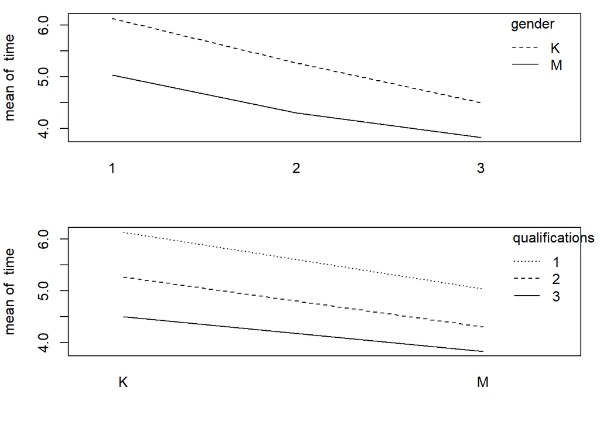

```r
op=par(mfrow=c(2,1))
par(mar=c(4.2, 4, 0.8, 1.1))
interaction.plot(qualifications, gender, time, xlab="")
interaction.plot(gender, qualifications, time, xlab="")
```

```r
TukeyHSD(aov(time ~ qualifications*gender))
```

```
##   Tukey multiple comparisons of means
##     95% family-wise confidence level
##
## Fit: aov(formula = time ~ qualifications * gender)
##
## $gender
##           diff       lwr        upr     p adj
## M-K -0.9111111 -1.319777 -0.5024456 0.0002924
```

Na podstawie przeprowadzonych testów możemy odrzucić hipotezę o równym czasie wykonania zadań przez osoby z danych biorąc pod uwagę jednocześnie ich kwalifikacje oraz płeć. Założenia analizy wariancji o równości warianckji oraz normalności danych są w tym przypadku spełnione. Z Testu Tukey’a oraz wykresów interakcji można wnioskować iż mężczyźni wykonują rozważane zadania szybciej oraz wzrost kwalifikacji jest zkorelowany ujemnie z czasem potrzebnym na wykonanie badanych czynności.